# Ford GoBike Ride Durations by Month and User Type

## by Ahmed Yasser Mostafa

## Investigation Overview

> The goal from this dataset was to figure out relationships between features and see which had the most impact on the duration of the rides.

## Dataset Overview

> This data set includes information about individual rides made in a bike-sharing system covering the San Francisco Bay area in 2017. This includes the duration of the ride, location of start and destination points and their start and end times.

## Distribution of Ride Durations

> Most of the rides take from 2 to 50 minutes.

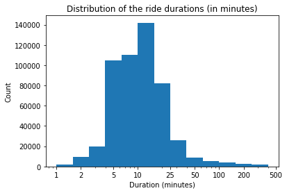

```python
bins = 10 ** np.arange(0, 2.56 + 0.2, 0.2)
plt.hist(data = df, x = 'duration_min', bins = bins);
plt.xscale('log');
plt.xticks([1, 2, 5, 10, 25, 50, 100, 200, 500], [1, 2, 5, 10, 25, 50, 100, 200, 500]);
plt.xlabel('Duration (minutes)');
plt.ylabel('Count');
plt.title('Distribution of the ride durations (in minutes)');
```

## Distribution of User Types

> The number of subscribers is almost 4 times the number of normal customers.

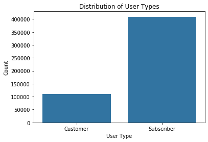

```python
sb.countplot(data = df, x = 'user_type', color = sb.color_palette()[0]);
plt.xlabel('User Type');
plt.ylabel('Count');
plt.title('Distribution of User Types');
```

## Distribution of Rides by Month

> The data only shows rides from june till the end of the year. Most of the rides are taken towards the end of the year (starting from August primarily) for both customers and subscribers.

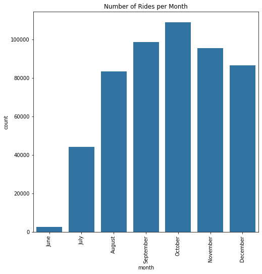

```python
ordered_months = ['June', 'July', "August", "September", "October", 'November', 'December']
months_order = pd.api.types.CategoricalDtype(ordered = True, categories = ordered_months)
df['month'] = df['month'].astype(months_order)
plt.figure(figsize = (8, 8));
sb.countplot(data = df, x = 'month', color = sb.color_palette()[0]);
plt.xticks(rotation = 90);
plt.title('Number of Rides per Month');
```

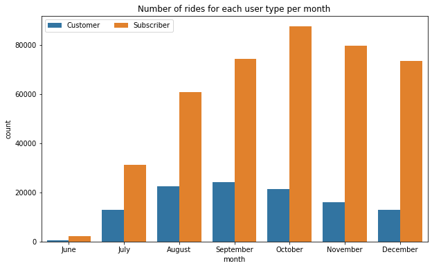

```python
plt.figure(figsize = (10,6))
ax = sb.countplot(data = df, x = 'month', hue = 'user_type');
ax.legend(loc = 0, ncol = 2);
plt.title('Number of rides for each user type per month');
```

## Relationship between Ride Duration and User Type

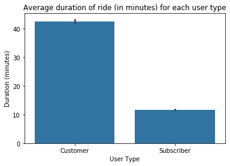

```python
sb.barplot(data = df, x = 'user_type', y = 'duration_min', color = sb.color_palette()[0]);
plt.xlabel('User Type');
plt.ylabel('Duration (minutes)');
plt.title('Average duration of ride (in minutes) for each user type');
```

### Now factoring in the same relationship for each month

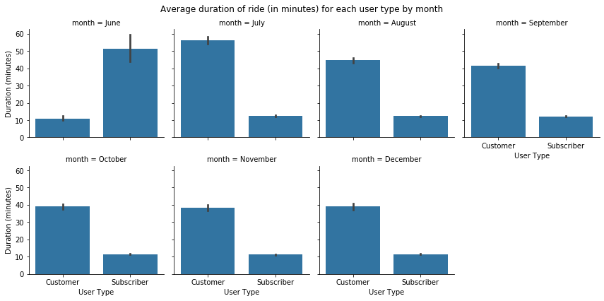

```python
g = sb.FacetGrid(data = df, col = 'month', size = 3, col_wrap = 4);
g = g.map(sb.barplot, 'user_type', 'duration_min', color = sb.color_palette()[0]);
g.set_xlabels('User Type');
g.set_ylabels('Duration (minutes)');
plt.subplots_adjust(top=0.9);
g.fig.suptitle('Average duration of ride (in minutes) for each user type by month');
```